> **Tip**: Welcome to the Investigate a Dataset project! You will find tips in quoted sections like this to help organize your approach to your investigation. Before submitting your project, it will be a good idea to go back through your report and remove these sections to make the presentation of your work as tidy as possible. First things first, you might want to double-click this Markdown cell and change the title so that it reflects your dataset and investigation.

# Project: tmdb-movies

- Introduction
- Data Wrangling
- Exploratory Data Analysis
- Conclusions

## Introduction

For this project i have chosen to look at the TMDB dataset. This data was provided as part of the Udacity Data Analysis Nanodegree and originated from Kaggle. it was originally sourced from IMDB but was replaced after takedown request.

Two main questions were investigated in the project:

1- Which genres are most popular from year to year? 2- What kinds of properties are associated with movies that have high revenues?

```python
# Use this cell to set up import statements for all of the packages that you
#   plan to use.

# Remember to include a 'magic word' so that your visualizations are plotted
#   inline with the notebook. See this page for more:
#   http://ipython.readthedocs.io/en/stable/interactive/magics.html
import numpy as np
import pandas as pd
import matplotlib.pyplot as plt
import seaborn as sns
import math
%matplotlib inline
```

## Data Wrangling

> **Tip**: In this section of the report, you will load in the data, check for cleanliness, and then trim and clean your dataset for analysis. Make sure that you document your steps carefully and justify your cleaning decisions.

### General Properties

```python
# Load your data and print out a few lines. Perform operations to inspect data
#   types and look for instances of missing or possibly errant data.
df = pd.read_csv("tmdb-movies.csv")
df.head()
```

|  | id | imdb_id | popularity | budget | revenue | original_title | cast | homepage | director | tagline | ... | overview | runtime | genres | production_companies | release_date | vote_count | vote_average | release_year | budget_adj | revenue_adj |
| --- | --- | --- | --- | --- | --- | --- | --- | --- | --- | --- | --- | --- | --- | --- | --- | --- | --- | --- | --- | --- | --- |
| 0 | 135397 | tt0369610 | 32.985763 | 150000000 | 1513528810 | Jurassic World | Chris Pratt\|Bryce Dallas Howard\|Irrfan Khan\|Vi... | http://www.jurassicworld.com/ | Colin Trevorrow | The park is open. | ... | Twenty-two years after the events of Jurassic ... | 124 | Action\|Adventure\|Science Fiction\|Thriller | Universal Studios\|Amblin Entertainment\|Legenda... | 6/9/15 | 5562 | 6.5 | 2015 | 1.379999e+08 | 1.392446e+09 |
| 1 | 76341 | tt1392190 | 28.419936 | 150000000 | 378436354 | Mad Max: Fury Road | Tom Hardy\|Charlize Theron\|Hugh Keays-Byrne\|Nic... | http://www.madmaxmovie.com/ | George Miller | What a Lovely Day. | ... | An apocalyptic story set in the furthest reach... | 120 | Action\|Adventure\|Science Fiction\|Thriller | Village Roadshow Pictures\|Kennedy Miller Produ... | 5/13/15 | 6185 | 7.1 | 2015 | 1.379999e+08 | 3.481613e+08 |
| 2 | 262500 | tt2908446 | 13.112507 | 110000000 | 295238201 | Insurgent | Shailene Woodley\|Theo James\|Kate Winslet\|Ansel... | http://www.thedivergentseries.movie/#insurgent | Robert Schwentke | One Choice Can Destroy You | ... | Beatrice Prior must confront her inner demons ... | 119 | Adventure\|Science Fiction\|Thriller | Summit Entertainment\|Mandeville Films\|Red Wago... | 3/18/15 | 2480 | 6.3 | 2015 | 1.012000e+08 | 2.716190e+08 |
| 3 | 140607 | tt2488496 | 11.173104 | 200000000 | 2068178225 | Star Wars: The Force Awakens | Harrison Ford\|Mark Hamill\|Carrie Fisher\|Adam D... | http://www.starwars.com/films/star-wars-episod... | J.J. Abrams | Every generation has a story. | ... | Thirty years after defeating the Galactic Empi... | 136 | Action\|Adventure\|Science Fiction\|Fantasy | Lucasfilm\|Truenorth Productions\|Bad Robot | 12/15/15 | 5292 | 7.5 | 2015 | 1.839999e+08 | 1.902723e+09 |
| 4 | 168259 | tt2820852 | 9.335014 | 190000000 | 1506249360 | Furious 7 | Vin Diesel\|Paul Walker\|Jason Statham\|Michelle ... | http://www.furious7.com/ | James Wan | Vengeance Hits Home | ... | Deckard Shaw seeks revenge against Dominic Tor... | 137 | Action\|Crime\|Thriller | Universal Pictures\|Original Film\|Media Rights ... | 4/1/15 | 2947 | 7.3 | 2015 | 1.747999e+08 | 1.385749e+09 |

5 rows × 21 columns

```python
#to know the dimensions of my data
df.shape
```

```
(10866, 21)
```

```python
# Count duplicate/non-duplicate rows
print(df.duplicated().sum())
```

```
1
```

```python
# Remove duplicate rows:
df.drop_duplicates(inplace= True)
print(df.duplicated().sum())
```

```
0
```

```python
# to know which columns that has missing values
df.info()
```

```
<class 'pandas.core.frame.DataFrame'>
Int64Index: 10865 entries, 0 to 10865
Data columns (total 21 columns):
 #   Column                Non-Null Count  Dtype
---  ------                --------------  -----
 0   id                    10865 non-null  int64
 1   imdb_id               10855 non-null  object
 2   popularity            10865 non-null  float64
 3   budget                10865 non-null  int64
 4   revenue               10865 non-null  int64
 5   original_title        10865 non-null  object
 6   cast                  10789 non-null  object
 7   homepage              2936 non-null   object
 8   director              10821 non-null  object
 9   tagline               8041 non-null   object
 10  keywords              9372 non-null   object
 11  overview              10861 non-null  object
 12  runtime               10865 non-null  int64
 13  genres                10842 non-null  object
 14  production_companies  9835 non-null   object
 15  release_date          10865 non-null  object
 16  vote_count            10865 non-null  int64
 17  vote_average          10865 non-null  float64
 18  release_year          10865 non-null  int64
 19  budget_adj            10865 non-null  float64
 20  revenue_adj           10865 non-null  float64
dtypes: float64(4), int64(6), object(11)
memory usage: 1.4+ MB
```

```python
# Remove the columns that are not useful to find the movies that have high revenues.

df.drop(['id','imdb_id','popularity','original_title','homepage','tagline','keywords','overview','vote_count','vote_average', 'budget_adj','revenue_adj'], axis = 1, inplace = True)
df.head()
```

|  | budget | revenue | cast | director | runtime | genres | production_companies | release_date | release_year |
| --- | --- | --- | --- | --- | --- | --- | --- | --- | --- |
| 0 | 150000000 | 1513528810 | Chris Pratt\|Bryce Dallas Howard\|Irrfan Khan\|Vi... | Colin Trevorrow | 124 | Action\|Adventure\|Science Fiction\|Thriller | Universal Studios\|Amblin Entertainment\|Legenda... | 6/9/15 | 2015 |
| 1 | 150000000 | 378436354 | Tom Hardy\|Charlize Theron\|Hugh Keays-Byrne\|Nic... | George Miller | 120 | Action\|Adventure\|Science Fiction\|Thriller | Village Roadshow Pictures\|Kennedy Miller Produ... | 5/13/15 | 2015 |
| 2 | 110000000 | 295238201 | Shailene Woodley\|Theo James\|Kate Winslet\|Ansel... | Robert Schwentke | 119 | Adventure\|Science Fiction\|Thriller | Summit Entertainment\|Mandeville Films\|Red Wago... | 3/18/15 | 2015 |
| 3 | 200000000 | 2068178225 | Harrison Ford\|Mark Hamill\|Carrie Fisher\|Adam D... | J.J. Abrams | 136 | Action\|Adventure\|Science Fiction\|Fantasy | Lucasfilm\|Truenorth Productions\|Bad Robot | 12/15/15 | 2015 |
| 4 | 190000000 | 1506249360 | Vin Diesel\|Paul Walker\|Jason Statham\|Michelle ... | James Wan | 137 | Action\|Crime\|Thriller | Universal Pictures\|Original Film\|Media Rights ... | 4/1/15 | 2015 |

```python
# get the number of nulls in each columns.
df.isnull().sum()
```

```
budget                     0
revenue                    0
cast                      76
director                  44
runtime                    0
genres                    23
production_companies    1030
release_date               0
release_year               0
dtype: int64
```

```python
# drop the nulls values from columns that has a small number of missing values (cast, director, genres)
# but use fillna function to fill null values that are in the production companies column.
df.dropna(subset=['cast','director','genres'],inplace=True)
df.fillna(method ='pad',inplace=True)
df.isnull().sum()
```

```
budget                  0
revenue                 0
cast                    0
director                0
runtime                 0
genres                  0
production_companies    0
release_date            0
release_year            0
dtype: int64
```

```python
# split the columns that contain the '|' character into multiple rows.
str_split = '|'

# Calculate maximum length of piped ('|') values
df['max_len'] = df[['cast', 'production_companies', 'genres']].apply(lambda x: max(len(x[0].split(str_split)), len(x[0].split(str_split))), axis=1)
max_len = df['max_len'].max()

# Split '|' piped cell values into columns (needed at unpivot step)
# Create as many new 'cast_<x>' & 'genres_<x>' & 'production_companies_<x>' columns as 'max_len'
df[['cast_{}'.format(i) for i in range(max_len)]] = df['cast'].apply(lambda x: pd.Series(x.split(str_split)))
df[['production_companies_{}'.format(i) for i in range(max_len)]] = df['production_companies'].apply(lambda x: pd.Series(x.split(str_split)))
df[['genres_{}'.format(i) for i in range(max_len)]] = df['genres'].apply(lambda x:pd.Series(x.split(str_split)))

# Unpivot 'cast_<x>' & 'genres_<x>' & 'production_companies_<x>' columns into rows
df_pv_cast = pd.melt(df, value_vars=['cast_{}'.format(i) for i in range(max_len)],id_vars=['budget', 'revenue','director','runtime','release_date','release_year'])
df_pv_production_companies = pd.melt(df, value_vars=['production_companies_{}'.format(i) for i in range(max_len)],id_vars=['budget', 'revenue','director','runtime','release_date','release_year'])
df_pv_genres = pd.melt(df, value_vars=['genres_{}'.format(i) for i in range(max_len)],id_vars=['budget', 'revenue','director','runtime','release_date','release_year'])

# Rename upivoted columns (these are the final columns)
df_pv_cast = df_pv_cast.rename(columns={'value':'cast'})
df_pv_production_companies = df_pv_production_companies.rename(columns={'value':'production_companies'})
df_pv_genres = df_pv_genres.rename(columns={'value':'genres'})
df.head()

# Rename 'cast_<x>' values (rows) to be 'key' for join (merge)
df_pv_cast['variable'] = df_pv_cast['variable'].map({'cast_{}'.format(i):'genres_{}'.format(i) for i in range(max_len)})

# Join unpivoted 'genres' & 'cast' dataframes
df_res = df_pv_genres.merge(df_pv_cast, on=['variable', 'budget', 'revenue','director','runtime','release_date','release_year'])

# Rename 'production_companies_<x>' values (rows) to be 'key' for join (merge)
df_pv_production_companies['variable'] = df_pv_production_companies['variable'].map({'production_companies_{}'.format(i):'genres_{}'.format(i) for i in range(max_len)})
# Join unpivoted (the previous dataframe) & 'production_companies' dataframes
df_res = df_res.merge(df_pv_production_companies, on=['variable', 'budget', 'revenue','director','runtime','release_date','release_year'])

# Drop 'variable' column and NULL rows if you have not equal pipe-length in original rows
df_res = df_res.drop(['variable'], axis=1).dropna(subset=['genres', 'cast','production_companies'], how='all',axis=0).reset_index(drop=True)
```

```python
# like we see we now have two dataframes.
# let's print them to see them.
```

```python
#the first one has 52723 rows becouse each 'actor' or 'genres' or 'production_companies' in separate rows.
df_res.head()
```

|  | budget | revenue | director | runtime | release_date | release_year | genres | cast | production_companies |
| --- | --- | --- | --- | --- | --- | --- | --- | --- | --- |
| 0 | 150000000 | 1513528810 | Colin Trevorrow | 124 | 6/9/15 | 2015 | Action | Chris Pratt | Universal Studios |
| 1 | 150000000 | 378436354 | George Miller | 120 | 5/13/15 | 2015 | Action | Tom Hardy | Village Roadshow Pictures |
| 2 | 110000000 | 295238201 | Robert Schwentke | 119 | 3/18/15 | 2015 | Adventure | Shailene Woodley | Summit Entertainment |
| 3 | 200000000 | 2068178225 | J.J. Abrams | 136 | 12/15/15 | 2015 | Action | Harrison Ford | Lucasfilm |
| 4 | 190000000 | 1506249360 | James Wan | 137 | 4/1/15 | 2015 | Action | Vin Diesel | Universal Pictures |

```python
# the second one has 10731 rows and 21 columns because the names did not split into separate rows but split into separate columns.
df_res2 = df.copy()

#drop columns (cast, genres, production_companies) from the second dataframe(df_res2)
df_res2.drop(['cast', 'genres', 'production_companies', 'max_len'], axis = 1, inplace = True)
df_res2.head(5)
```

|  | budget | revenue | director | runtime | release_date | release_year | cast_0 | cast_1 | cast_2 | cast_3 | ... | production_companies_0 | production_companies_1 | production_companies_2 | production_companies_3 | production_companies_4 | genres_0 | genres_1 | genres_2 | genres_3 | genres_4 |
| --- | --- | --- | --- | --- | --- | --- | --- | --- | --- | --- | --- | --- | --- | --- | --- | --- | --- | --- | --- | --- | --- |
| 0 | 150000000 | 1513528810 | Colin Trevorrow | 124 | 6/9/15 | 2015 | Chris Pratt | Bryce Dallas Howard | Irrfan Khan | Vincent D'Onofrio | ... | Universal Studios | Amblin Entertainment | Legendary Pictures | Fuji Television Network | Dentsu | Action | Adventure | Science Fiction | Thriller | NaN |
| 1 | 150000000 | 378436354 | George Miller | 120 | 5/13/15 | 2015 | Tom Hardy | Charlize Theron | Hugh Keays-Byrne | Nicholas Hoult | ... | Village Roadshow Pictures | Kennedy Miller Productions | NaN | NaN | NaN | Action | Adventure | Science Fiction | Thriller | NaN |
| 2 | 110000000 | 295238201 | Robert Schwentke | 119 | 3/18/15 | 2015 | Shailene Woodley | Theo James | Kate Winslet | Ansel Elgort | ... | Summit Entertainment | Mandeville Films | Red Wagon Entertainment | NeoReel | NaN | Adventure | Science Fiction | Thriller | NaN | NaN |
| 3 | 200000000 | 2068178225 | J.J. Abrams | 136 | 12/15/15 | 2015 | Harrison Ford | Mark Hamill | Carrie Fisher | Adam Driver | ... | Lucasfilm | Truenorth Productions | Bad Robot | NaN | NaN | Action | Adventure | Science Fiction | Fantasy | NaN |
| 4 | 190000000 | 1506249360 | James Wan | 137 | 4/1/15 | 2015 | Vin Diesel | Paul Walker | Jason Statham | Michelle Rodriguez | ... | Universal Pictures | Original Film | Media Rights Capital | Dentsu | One Race Films | Action | Crime | Thriller | NaN | NaN |

5 rows × 21 columns

```python
# caluculate the number of null values in each column
print ("the number of null values before use fillna()\n",df_res2.isnull().sum())
print ("**********************************************************************************")

# Using fillna() to fill values from another column (first column because every column
# must have atleast one actor, director, and production_companies ).
for i in range(1,5):
    df_res2[f'cast_{i}'].fillna(df['cast_0'], inplace= True)
    df_res2[f'production_companies_{i}'].fillna(df['production_companies_0'], inplace= True)
    df_res2[f'genres_{i}'].fillna(df['genres_0'], inplace= True)
print ("the number of null values before use fillna()\n",df_res2.isnull().sum())
print (df_res2.shape)

df_res2.head()
```

```
the number of null values before use fillna()
 budget                        0
revenue                       0
director                      0
runtime                       0
release_date                  0
release_year                  0
cast_0                        0
cast_1                      137
cast_2                      221
cast_3                      327
cast_4                      636
production_companies_0        0
production_companies_1     3804
production_companies_2     6628
production_companies_3     8527
production_companies_4     9515
genres_0                      0
genres_1                   2271
genres_2                   5680
genres_3                   8759
genres_4                  10192
dtype: int64
the number of null values before use fillna()
 budget                    0
revenue                   0
director                  0
runtime                   0
release_date              0
release_year              0
cast_0                    0
cast_1                    0
cast_2                    0
cast_3                    0
cast_4                    0
production_companies_0    0
production_companies_1    0
production_companies_2    0
production_companies_3    0
production_companies_4    0
genres_0                  0
genres_1                  0
genres_2                  0
genres_3                  0
genres_4                  0
dtype: int64
(10731, 21)
```

|  | budget | revenue | director | runtime | release_date | release_year | cast_0 | cast_1 | cast_2 | cast_3 | ... | production_companies_0 | production_companies_1 | production_companies_2 | production_companies_3 | production_companies_4 | genres_0 | genres_1 | genres_2 | genres_3 | genres_4 |
| --- | --- | --- | --- | --- | --- | --- | --- | --- | --- | --- | --- | --- | --- | --- | --- | --- | --- | --- | --- | --- | --- |
| 0 | 150000000 | 1513528810 | Colin Trevorrow | 124 | 6/9/15 | 2015 | Chris Pratt | Bryce Dallas Howard | Irrfan Khan | Vincent D'Onofrio | ... | Universal Studios | Amblin Entertainment | Legendary Pictures | Fuji Television Network | Dentsu | Action | Adventure | Science Fiction | Thriller | Action |
| 1 | 150000000 | 378436354 | George Miller | 120 | 5/13/15 | 2015 | Tom Hardy | Charlize Theron | Hugh Keays-Byrne | Nicholas Hoult | ... | Village Roadshow Pictures | Kennedy Miller Productions | Village Roadshow Pictures | Village Roadshow Pictures | Village Roadshow Pictures | Action | Adventure | Science Fiction | Thriller | Action |
| 2 | 110000000 | 295238201 | Robert Schwentke | 119 | 3/18/15 | 2015 | Shailene Woodley | Theo James | Kate Winslet | Ansel Elgort | ... | Summit Entertainment | Mandeville Films | Red Wagon Entertainment | NeoReel | Summit Entertainment | Adventure | Science Fiction | Thriller | Adventure | Adventure |
| 3 | 200000000 | 2068178225 | J.J. Abrams | 136 | 12/15/15 | 2015 | Harrison Ford | Mark Hamill | Carrie Fisher | Adam Driver | ... | Lucasfilm | Truenorth Productions | Bad Robot | Lucasfilm | Lucasfilm | Action | Adventure | Science Fiction | Fantasy | Action |
| 4 | 190000000 | 1506249360 | James Wan | 137 | 4/1/15 | 2015 | Vin Diesel | Paul Walker | Jason Statham | Michelle Rodriguez | ... | Universal Pictures | Original Film | Media Rights Capital | Dentsu | One Race Films | Action | Crime | Thriller | Action | Action |

5 rows × 21 columns

> **Tip**: You should *not* perform too many operations in each cell. Create cells freely to explore your data. One option that you can take with this project is to do a lot of explorations in an initial notebook. These don't have to be organized, but make sure you use enough comments to understand the purpose of each code cell. Then, after you're done with your analysis, create a duplicate notebook where you will trim the excess and organize your steps so that you have a flowing, cohesive report.

> **Tip**: Make sure that you keep your reader informed on the steps that you are taking in your investigation. Follow every code cell, or every set of related code cells, with a markdown cell to describe to the reader what was found in the preceding cell(s). Try to make it so that the reader can then understand what they will be seeing in the following cell(s).

## Exploratory Data Analysis

> **Tip**: Now that you've trimmed and cleaned your data, you're ready to move on to exploration. Compute statistics and create visualizations with the goal of addressing the research questions that you posed in the Introduction section. It is recommended that you be systematic with your approach. Look at one variable at a time, and then follow it up by looking at relationships between variables.

### Research Question 1 (Which genres are most popular from year to year?)

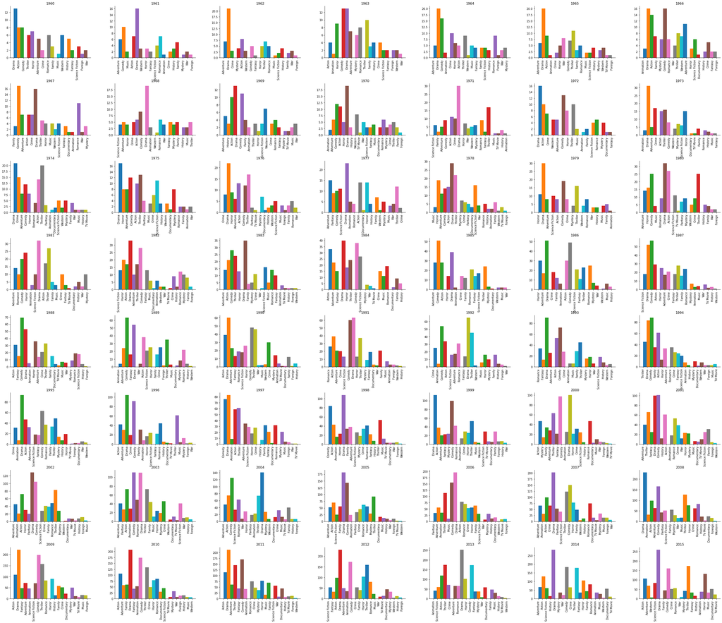

```python
#here i use the df_res dataframe because i need every genre in a separate row.

#plot bar charts for each separete year
axes = df_res['genres'].hist(by=df_res['release_year'], figsize = (45,40), bins=22);

# Define a different color for the bars
colors = ['#1f77b4', '#ff7f0e', '#2ca02c', '#d62728', '#9467bd', '#8c564b', '#e377c2', '#7f7f7f', '#bcbd22', '#17becf','#1f77b4','#ff7f0e','#2ca02c' ,'#d62728','#9467bd','#8c564b','#e377c2','#7f7f7f','#bcbd22','#17becf']

for i, ax in enumerate(axes.reshape(-1)):
    # Define a counter to ensure that if we have more than 19 bars with a value,
    # we don't try to access out-of-range element in colors
    k = 0

    # Optional: remove grid, and top and right spines
    ax.grid(False)
    ax.spines['top'].set_visible(False)
    ax.spines['right'].set_visible(False)

    for rect in ax.patches:
        # If there's a value in the rect and we have defined a color
        if rect.get_height() > 0 and k < len(colors):
            # Set the color
            rect.set_color(colors[k])
            # Increment the counter
            k += 1

plt.show()
```

The previous figures show how to change the genres of movies most watched and most popular from year to year from 1960 to 2015

We note that no type of film is fixed over these years. Rather, all types of films change in proportion from year to year, due to several factors that will be mentioned later, such as the cast, director, runtime......etc.

### Research Question 2 (What kinds of properties are associated with movies that have high revenues?)

```python
def line_chart(d, title, xlabel, ylabel):
    #plot and show the effect of the directors on revenue.
    d.plot(legend=True, figsize = (18,10));

    plt.xlabel(xlabel,fontsize = 15)
    plt.ylabel(ylabel,fontsize = 15)
    plt.title(title,fontsize = 20 )
    plt.ylim(0, None)

    temp = [i for i in range(0,len(d), math.ceil(len(d)/35))]
    plt.xticks( temp, temp, fontsize = 11, rotation=45)    # changing x scale by own
    plt.show()
```

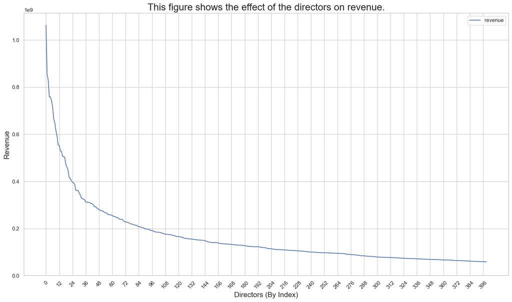

```
director
Lee Unkrich           1.063172e+09
Pete Docter           8.537086e+08
David Yates           8.308591e+08
Colin Trevorrow       7.587683e+08
Robert Stromberg      7.584104e+08
                          ...
Lasse HallstrÃ¶m      5.952601e+07
Dustin Hoffman        5.952030e+07
Andrzej Bartkowiak    5.924729e+07
Mark Helfrich         5.919213e+07
Joel Edgerton         5.897865e+07
Name: revenue, Length: 400, dtype: float64
```

```python
# here i drop all rows that contain a special character( '|' ) in their director column
#because the number of them about 400 directors, so i think they are not make a big affect on my results.
df_res3 = df_res2.copy()
df_res3.drop(df_res2[df_res2.director.str.contains(r'[|]')].index, inplace = True)


# use groupby() function to show the average of revenue for each director depend on his films.
# i use the mean because maybe one director makes alot of films so he gain a lot of revenues but there is another
# director make one or two films only but he is more better than the first one, but he doesn't earn much revenue
#because he may be young or starting his career soon.
final_df = df_res3.groupby('director').revenue.mean()

# sort my datadrame
d = final_df.sort_values(ascending=False).head(400)

#plot line chart
line_chart(d, "This figure shows the effect of the directors on revenue.","Directors (By Index)","Revenue" )

#print the datafram
d
```

The first figure is the line chart, which represents how the directors of films affect the revenues of the film, I examined only 400 samples, but if you want to be higher or lower, just add the number inside the code. And if you want to achieve high revenues from the film, you should choose about the first 120 directors from my list, but if you choose a director after the 120th order, the curve of the level of revenues will go down, and therefore it is possible not to achieve high revenues.

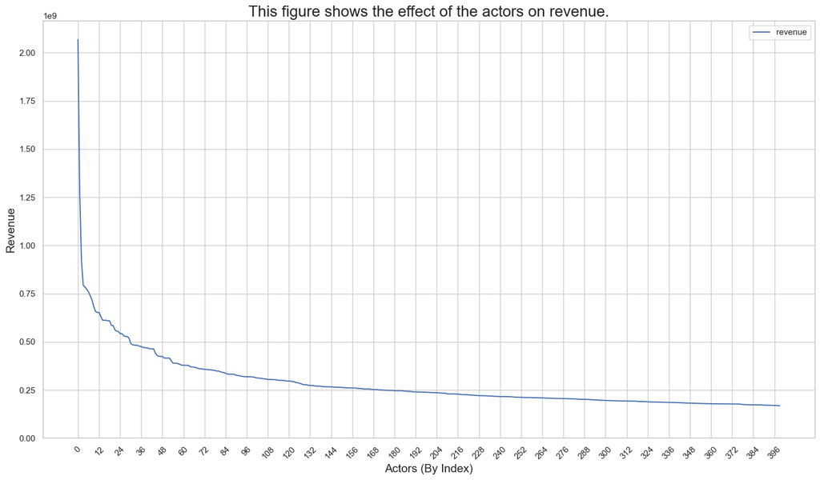

```
cast
Daisy Ridley          2.068178e+09
Santino Fontana       1.274219e+09
Bob Peck              9.201000e+08
Robert MacNaughton    7.929106e+08
Rosemary Harris       7.837663e+08
                          ...
Zhang Ziyi            1.701954e+08
Anna Hoelck           1.699568e+08
Brady Bluhm           1.698370e+08
Callan Mulvey         1.687900e+08
Sarah Jane Morris     1.681677e+08
Name: revenue, Length: 400, dtype: float64
```

```python
#here i use the df_res dataframe because i need every actor in a separate row.

# use groupby() function to show the average of revenue for each actor depend on his films.
# i use the mean because maybe one actor makes alot of films so he gain a lot of revenues but there is another
# actor make one or two films only but he is more better than the first one, but he doesn't earn much revenue
# because he may be young or starting his career soon.
final_df = df_res.groupby('cast').revenue.mean()

# sort my datadrame
d = final_df.sort_values(ascending=False).head(400)


#plot line chart
line_chart(d, "This figure shows the effect of the actors on revenue.","Actors (By Index)","Revenue" )

#print the datafram
d
```

In the second line chart, which shows the effect of casting on revenues, as is the case with the first line chart, but here if you want to achieve good revenues, you should choose the casting team to be most of the first 200 actors in my list, they will guarantee you a large percentage of achievement High revenue.

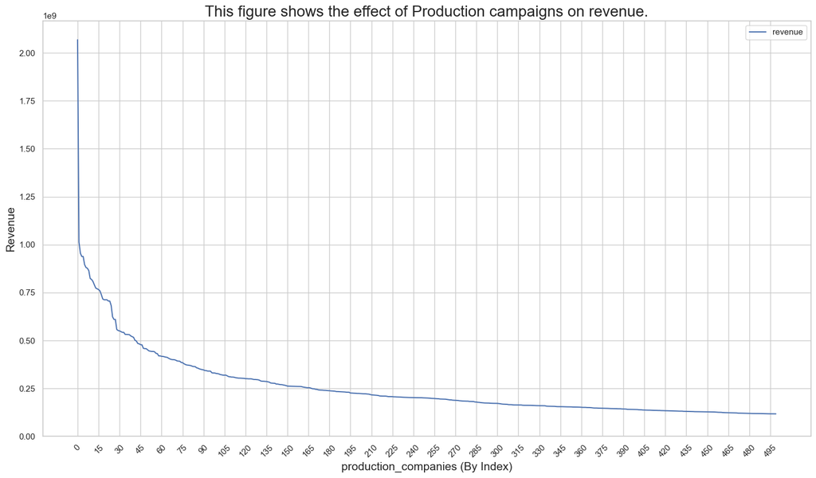

```
production_companies
Truenorth Productions             2.068178e+09
Second Mate Productions           1.013330e+09
3Foot7                            9.551198e+08
Harry Potter Publishing Rights    9.382127e+08
Cool Music                        9.382127e+08
                                      ...
See Me Louisiana                  1.176989e+08
LivePlanet                        1.175318e+08
Finestkind                        1.174875e+08
Black and Blu Entertainment       1.174875e+08
New Legacy                        1.173578e+08
Name: revenue, Length: 500, dtype: float64
```

```python
#here i use the df_res dataframe because i need every actor in a separate row.

final_df = df_res.groupby("production_companies").revenue.mean()
final_df = final_df.sort_values(ascending=False).head(500)

#plot line chart
line_chart(final_df, "This figure shows the effect of Production campaigns on revenue.","production_companies (By Index)","Revenue" )

#print the datafram
final_df
```

The same thing is what happens with the third line chart, which shows the effect of production companies on the revenues of films, and we also note that there is a great influence in choosing the appropriate production companies to produce your films and achieve high revenues, and also to ensure high revenues you have to choose production companies Only from the first 180 companies from my ranked list, and if companies are selected after the 180th rank, then you will risk the success of the film and you will risk achieving high revenues or not.

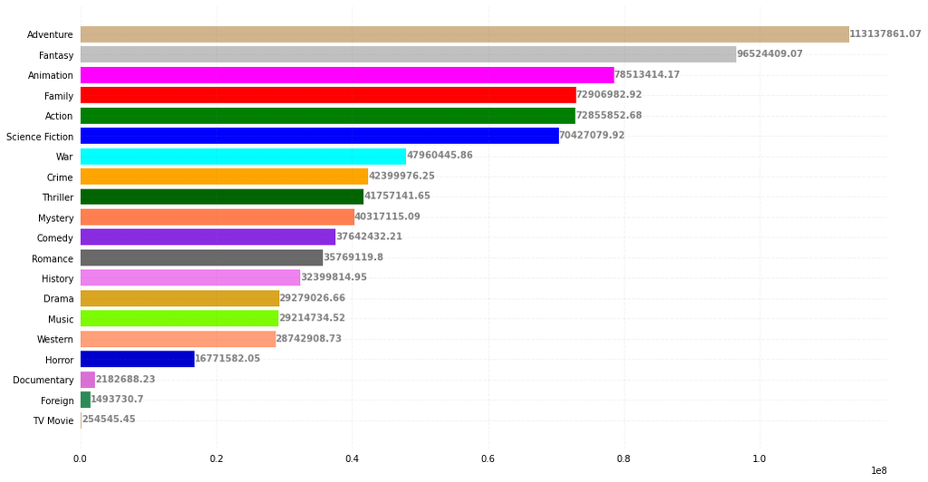

```python
#here i use the df_res dataframe because i need every genre in a separate row.

# use groupby() function to show the average of revenue for each genre of films.
final_df = df_res.groupby('genres').revenue.mean()

# sort my datadrame
w = final_df.sort_values(ascending=False)
d = pd.DataFrame(w)
d = d.reset_index()

#plot and show the effect of the genres on revenue.
fig, ax = plt.subplots(figsize =(16, 9))
ax.barh(d['genres'], d['revenue'],color=['tan','silver','fuchsia', 'red', 'green', 'blue', 'cyan','orange','darkgreen','coral','blueviolet', 'dimgray', 'violet','goldenrod','lawngreen','lightsalmon','mediumblue','orchid','seagreen'])

# Remove axes splines
for s in ['top', 'bottom', 'left', 'right']:
    ax.spines[s].set_visible(False)

# Remove x, y Ticks
ax.xaxis.set_ticks_position('none')
ax.yaxis.set_ticks_position('none')

# Add x, y gridlines
ax.grid(b = True, color ='grey', linestyle ='-.', linewidth = 0.5, alpha = 0.2)

# Show top values
ax.invert_yaxis()

# Add annotation to bars
for i in ax.patches:
    plt.text(i.get_width()+0.2, i.get_y()+0.5, str(round((i.get_width()), 2)), fontsize = 10, fontweight ='bold', color ='grey')

# Add Plot Title
ax.set_title('', loc ='left', )

# Show Plot
plt.show()
```

The fourth figure represents the horizontal bar chart, which represents the most widespread types of films that achieve the highest revenues. As we can see, the Adventures films top the list and TV Movies remove the list, and according to this figure, it is preferable that the type of film you produce be one of the following types (Adventures, fantasy, animation, family, action, Sience fiction) because the seventh film in the ranking, which is the war movies, is far from the sixth type in terms of revenue generation, and it is also clear from the graph that the genre of the film directly affects the volume of sales and revenue because of the preference for People are more interested in certain types of films than others.

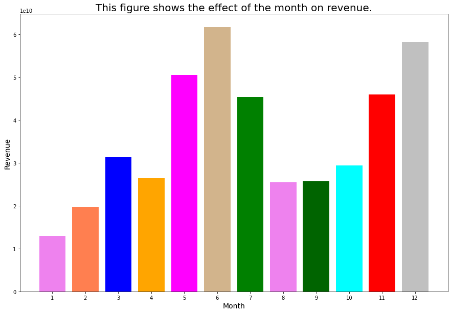

```python
from datetime import datetime
# here i use the df res2 dataframe because i don't need multiple repeated row
# from revenue because that will has a gig affect on the summation of revenue for each month.

# extract the month from the release_date
m = []
for value in df_res2['release_date']:
    datem = datetime.strptime(value, "%m/%d/%y")
    m.append(datem.month)
df_res2['month'] = m

# use groupby() function to show the summation of revenue for each month.
final_df = df_res2.groupby('month').revenue.sum()

# sort my datadrame
final_df = final_df.sort_values(ascending=False)
final_df = pd.DataFrame(final_df)
final_df = final_df.reset_index()


plt.figure(figsize=(15, 10))
plt.bar(final_df['month'], final_df['revenue'],color=['tan','silver','fuchsia', 'red', 'green', 'blue', 'cyan','orange','darkgreen','violet','coral','violet'])
plt.ylabel('Revenue',  fontsize = 14)
plt.xlabel('Month', fontsize = 14)
plt.title("This figure shows the effect of the month on revenue.",fontsize = 20)
plt.xticks( [i for i in range (1,13)] , fontsize = 10)    # changing x scale by own


# Show Plot
plt.show();
```

The fifth figure represents a bar chart showing the effect of the month in which the movie is released on the amount of revenue that the movie earns, As we can see here that the highest two months in terms of revenue are the months of June and December, and this certainly has many reasons. It is possible that these two months are the months of official holidays in many countries, or that these two months have important occasions or the date of the beginning of the spring and autumn seasons, and therefore the weather is mild. Which encourages people to get out of their homes and go to the cinema.

```python
def scatterplot(data1, data2, title, xlabel, ylabel, ylim_1,ylim_2, xlim_1, xlim_2):
    plt.scatter(data1, data2 );
    plt.rcParams.update({'figure.figsize':(15,8), 'figure.dpi':100})
    plt.title(title,fontsize = 20)
    plt.xlabel(xlabel,fontsize = 14)
    plt.ylabel(ylabel,fontsize = 14)
    plt.ylim(ylim_1,ylim_2)
    plt.xlim(xlim_1, xlim_2)
    plt.figure(figsize=(15, 10))
    plt.show();
```

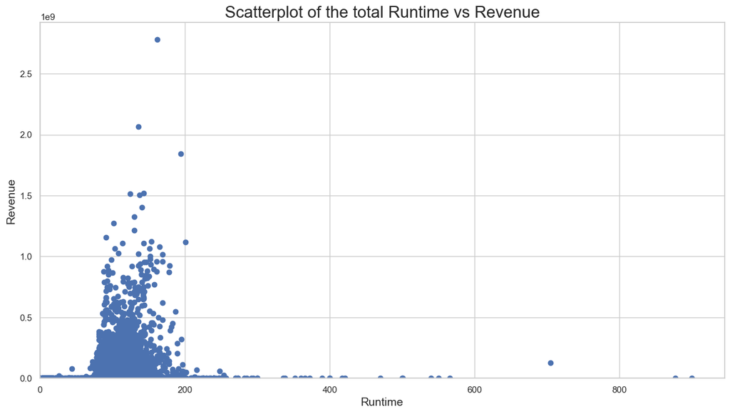

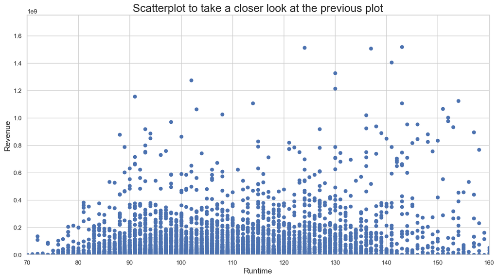

```python
# here i use the df res2 dataframe because i don't need multiple repeated row
# from revenue because that will has a gig affect on my analysis.


# extract the two columns that i want to show the correlation between them.
runtime = df_res2['runtime']
revenue = df_res2['revenue']


# plot a Scatter plot to show the correlation between total Runtime for each film and its Revenue.
scatterplot(runtime, revenue, 'Scatterplot of the total Runtime vs Revenue', 'Runtime', 'Revenue', 0,None,0,None );

#plot another scatterplot to see the correlation more obvious
# by take a close look on the range that has a big number of points in the previous graph.
scatterplot(runtime, revenue, 'Scatterplot to take a closer look at the previous plot', 'Runtime', 'Revenue', 0,1.75e9,70,160 );
```

In the sixth figure, a scatterplot was drawn, and it shows the appropriate film duration that people prefer, which positively affects the revenues, It is preferable that the duration of the film ranges from 90 to 140 minutes, because this period is the one that brings more revenue and therefore people prefer it.

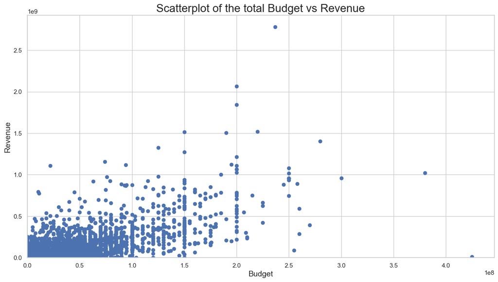

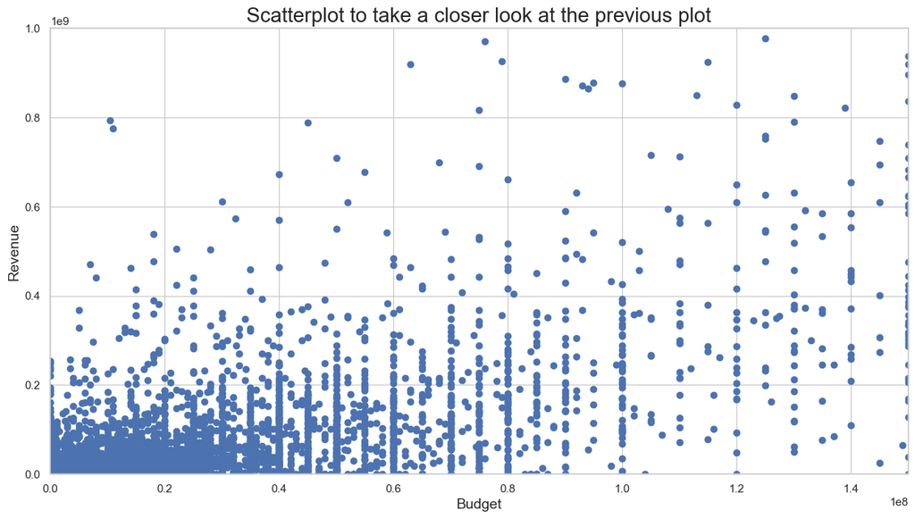

```python
# here i use the df res2 dataframe because i don't need multiple repeated row
# from revenue because that will has a gig affect on my analysis.


# extract the two columns that i want to show the correlation between them.
budget = df_res2['budget']
revenue = df_res2['revenue']

# plot a Scatter plot to show the correlation between total budget for each film and its Revenue.
scatterplot(budget, revenue, 'Scatterplot of the total Budget vs Revenue', 'Budget', 'Revenue', 0,None,0,None );

# plot another scatterplot to see the correlation more obvious
# by take a close look on the range that has a big number of points in the previous graph.
scatterplot(budget, revenue, 'Scatterplot to take a closer look at the previous plot', 'Budget', 'Revenue', 0,1e9,0,1.5e8 );
```

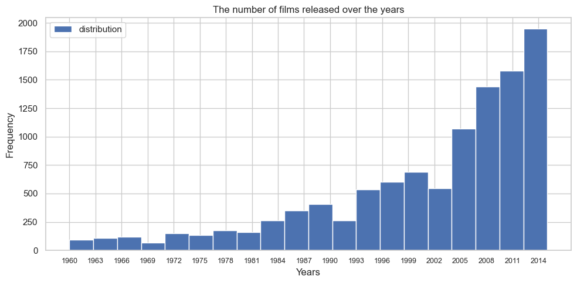

```python
from matplotlib import colors
from matplotlib.ticker import PercentFormatter

# Creating dataset
data = df_res2["release_year"]
data = pd.DataFrame(data)

# Creating histogram
fig, axs = plt.subplots(1, 1, figsize =(10, 5), tight_layout = True)

axs.hist(data, bins = n_bins)

# Adding extra features
plt.xlabel("Years")
plt.ylabel("Frequency")
plt.legend(legend)
plt.title('The number of films released over the years')

temp = [i for i in range(1960,2016,3)]
plt.xticks(temp,temp, fontsize = 9)    # changing x scale by own


# Show plot
plt.show()
```

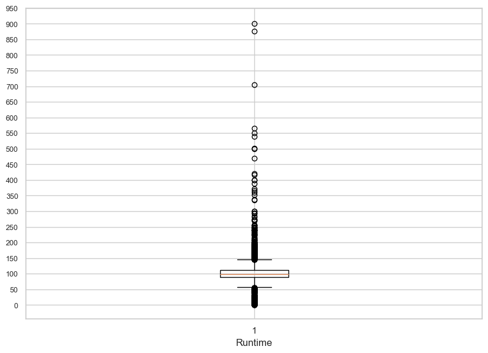

```
count    10731.000000
mean       102.468829
std         30.493873
min          0.000000
25%         90.000000
50%         99.000000
75%        112.000000
max        900.000000
Name: runtime, dtype: float64
```

```python
fig = plt.figure(figsize =(10, 7))

# Creating plot
plt.boxplot(df_res2["runtime"])
plt.xlabel("Runtime")

temp = [i for i in range(0,1000,50)]
plt.yticks(temp,temp, fontsize = 9)    # changing x scale by own

# show plot
plt.show()

#getting specific runtime
df['runtime'].describe()
```

The box-plot gives us an overall idea of how spread the distribution is in the case of the runtime of the movies. It also shows the outliers here. By looking at both of the plots and calculations, we can conclude that:

25% of the movies have a runtime of fewer than 90 minutes 50% (median) of movies have a runtime of fewer than 99 minutes. 75% of movies have a runtime of fewer than 112 minutes

## Conclusions

After this interesting analysis for the TMDb dataset and abstract conclusions after each analysis or visualization step here are some final thoughts:

For a Movie in order to be considered in a successful criteria

4- You must choose the first 6 genres in the list you created above to achieve at least 704,27079.92 revenue.

6- You must select the first 90 directors in the list you created above to achieve at least 0.2e9 revenue.

7- The film must be released during the month of December and June to ensure maximum revenue.

Limitation: 1- The revenue column does not have a currency unit, so it may be possible different movies have a budget in the different currencies according to the country they are produced in. So an inconsistency appears here which can state the complete analysis wrong.

2- International laws that differ from one country to another may prevent the showing of certain films within their country because these films violate the values and standards of their societies, or because of political differences with the country producing these films, and thus this directly affects the revenues, although the film may be successful in the country the other.